# Bivariate Mixed Model

Sushrut Vyawahare

31 August 2019

#### Loading Required Libraries.

```r
library(dplyr)
library(nlme)
```

```r
library(lattice)
library(ggplot2)
```

#### Load Fetal Growth Data.

```r
fetal_grw <- load("C:/Users/DELL/Documents/R Script/Weight Gain/data_for_fetalGrowth.RData")
str(fetal_grw)
```

```
##  chr "dat_for_fg"
```

```r
fetal_grw <- dat_for_fg
dim(fetal_grw)
```

```
## [1] 8561    3
```

```r
fetal_grw$fw <- fetal_grw$fw/1000
```

#### Finding NA values is data.

```r
sum(is.na(fetal_grw))
```

```
## [1] 0
```

#### Summary of fetal Growth Data.

```r
summary(fetal_grw)
```

```
##     enrid                 fw                pog
##  Length:8561        Min.   : 0.07586   Min.   :11.57
##  Class :character   1st Qu.: 0.29565   1st Qu.:19.86
##  Mode  :character   Median : 1.56355   Median :30.86
##                     Mean   : 1.66887   Mean   :30.56
##                     3rd Qu.: 2.62400   3rd Qu.:38.71
##                     Max.   :22.75000   Max.   :44.29
```

#### Box Plot- Analysing outlier and droping outlier.

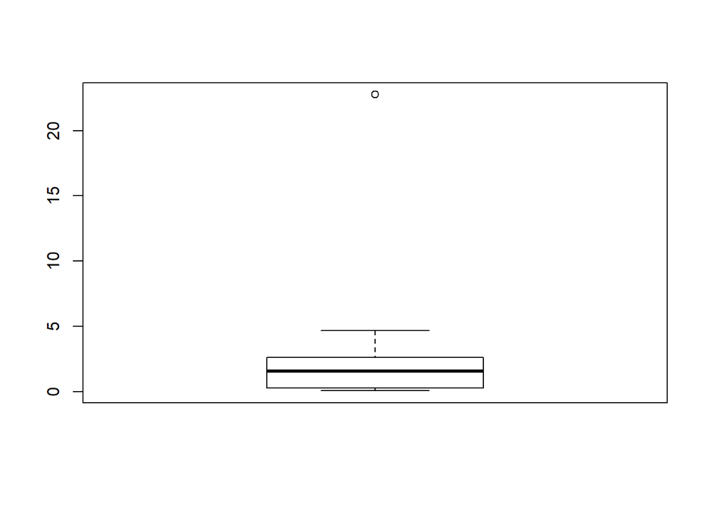

```
## [1] 22.75
```

```r
boxplot(fetal_grw$fw)$out
```

```r
boxplot(fetal_grw$fw, plot=FALSE)$out
```

```
## [1] 22.75
```

```r
outliers <- boxplot(fetal_grw$fw, plot=FALSE)$out
```

```r
fetal_grw[which(fetal_grw$fw %in% outliers),]
```

```
##        enrid    fw      pog
## 17403 E04093 22.75 38.71429
```

```r
fetal_grw <- fetal_grw[-which(fetal_grw$fw %in% outliers),]
```

#### Scatter Plot of pog Vs. fw

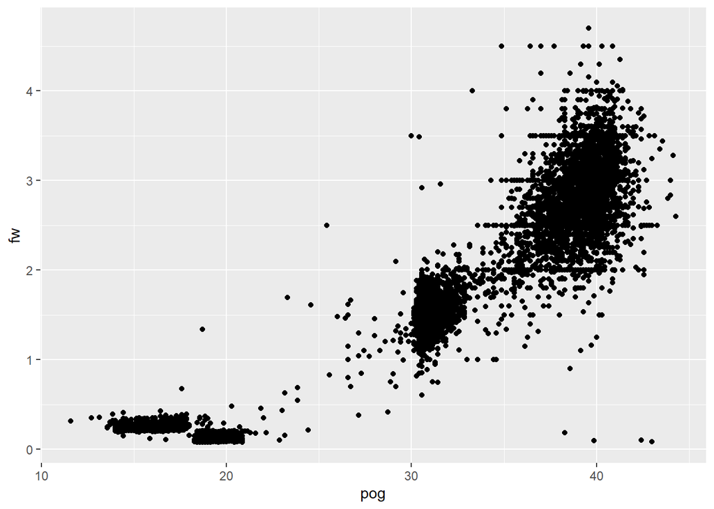

```r
ggplot(fetal_grw, aes(x = pog, y = fw)) + geom_point()
```

#### Creating New varible.

```r
fetal_grw$Group <- "f_gwth"
str(fetal_grw)
```

```
## 'data.frame':    8560 obs. of  4 variables:
##  $ enrid: chr  "E00001" "E00004" "E00005" "E00007" ...
##  $ fw   : num  0.264 0.286 0.303 0.237 0.282 ...
##  $ pog  : num  14 16.7 16.4 15.1 15.4 ...
##  $ Group: chr  "f_gwth" "f_gwth" "f_gwth" "f_gwth" ...
```

```r
names(fetal_grw) <- c("enrid","value_wt","pog","variable")
```

#### Load Weight gain data.

```r
wt_gain <- load("C:/Users/DELL/Documents/R Script/Weight Gain/data_for_fetalGrowth_wt_gain.RData")
str(wt_gain)
```

```
##  chr "dat_for_fg"
```

```r
wt_gain <- dat_for_fg
```

```r
dim(wt_gain)
```

```
## [1] 14170     3
```

#### Finding NA values is data.

```r
sum(is.na(wt_gain))
```

```
## [1] 0
```

#### Summary of weight gain data.

```r
summary(wt_gain)
```

```
##     enrid                pog            wt_gain
##  Length:14170       Min.   : 5.714   Min.   :-22.500
##  Class :character   1st Qu.:18.429   1st Qu.:  0.000
##  Mode  :character   Median :26.143   Median :  2.600
##                     Mean   :24.075   Mean   :  3.513
##                     3rd Qu.:30.714   3rd Qu.:  5.950
##                     Max.   :44.143   Max.   : 72.260
```

#### Box plot

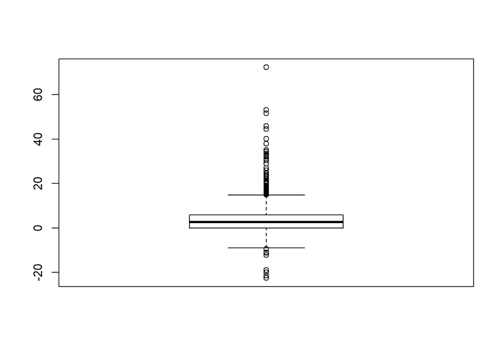

```r
boxplot(wt_gain$wt_gain)
```

#### Scatter plot of pog Vs. wt_gain

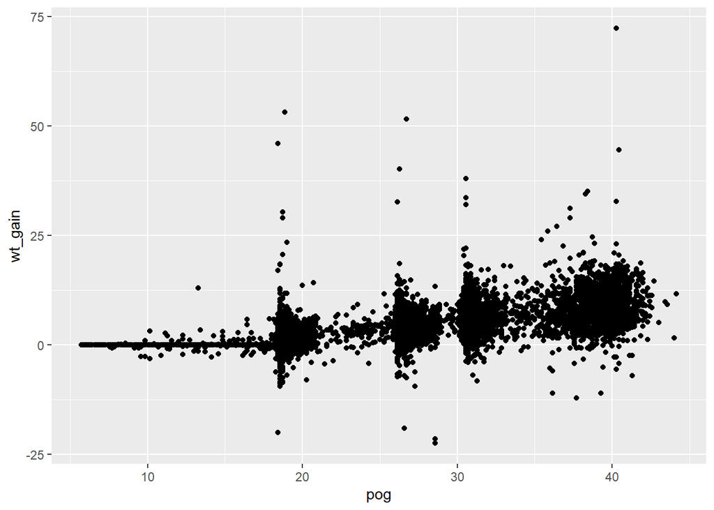

```r
ggplot(wt_gain, aes(x = pog, y = wt_gain)) + geom_point()
```

```r
wt_gain$Group <- "wt_gain"
str(wt_gain)
```

```
## 'data.frame':    14170 obs. of  4 variables:
##  $ enrid  : chr  "E00003" "E00005" "E00006" "E00007" ...
##  $ pog    : num  18.29 16.43 12.14 15.29 9.86 ...
##  $ wt_gain: num  0 0 0 0 0 0 0 0 0 0 ...
##  $ Group  : chr  "wt_gain" "wt_gain" "wt_gain" "wt_gain" ...
```

#### Changing the colnames names

```r
names(wt_gain) <- c("enrid","value_wt","pog","variable")
```

#### Combining both data.

```r
new_data <- rbind(fetal_grw,wt_gain)
new_data$value_wt <- log(new_data$value_wt)
dim(new_data)
```

```
## [1] 22730     4
```

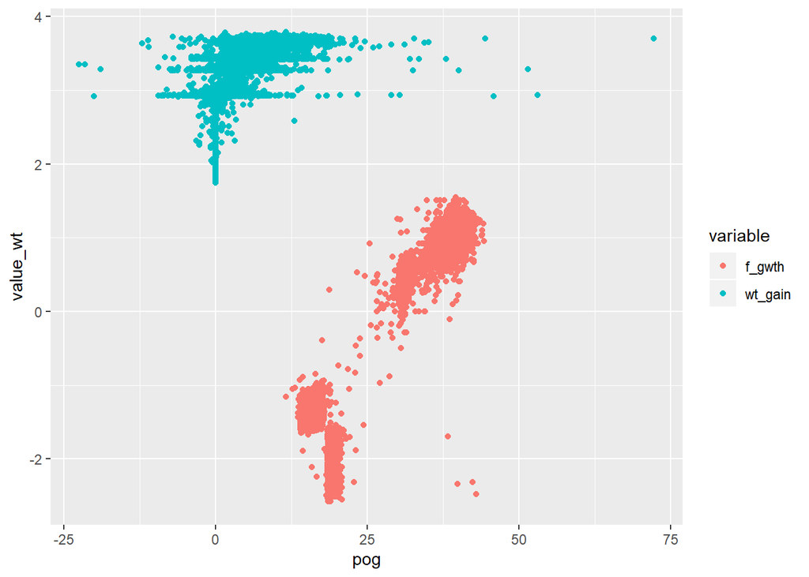

```r
ggplot(new_data, aes(x = pog,y = value_wt,fill = variable, color = variable)) + geom_point()
```

##### Creating dummy variables for grwth and wt_gain.Dl and De are 0/1 dummy variables coding whether the outcome is the varialbe f_gwth or wt_gain. enrid is now repeated many times and pog is repeated twice, once for each outcome variable.

```r
head(new_data)
```

```
##     enrid  value_wt      pog variable
## 1  E00001 -1.331944 14.00000   f_gwth
## 4  E00004 -1.250115 16.71429   f_gwth
## 5  E00005 -1.192711 16.42857   f_gwth
## 7  E00007 -1.440507 15.14286   f_gwth
## 10 E00010 -1.265430 15.42857   f_gwth
## 11 E00011 -1.231557 17.14286   f_gwth
```

```r
new_data$De <- ifelse(new_data$variable == 'wt_gain',1,0)
new_data$Dl <- ifelse(new_data$variable == 'f_gwth',1,0)
```

```r
str(new_data)
```

```
## 'data.frame':    22730 obs. of  6 variables:
##  $ enrid   : chr  "E00001" "E00004" "E00005" "E00007" ...
##  $ value_wt: num  -1.33 -1.25 -1.19 -1.44 -1.27 ...
##  $ pog     : num  14 16.7 16.4 15.1 15.4 ...
##  $ variable: chr  "f_gwth" "f_gwth" "f_gwth" "f_gwth" ...
##  $ De      : num  0 0 0 0 0 0 0 0 0 0 ...
##  $ Dl      : num  1 1 1 1 1 1 1 1 1 1 ...
```

```r
new_data$variable <- as.factor(new_data$variable)
new_data$De <- as.integer(new_data$De)
new_data$Dl <- as.integer(new_data$Dl)
new_data$enrid <- as.factor(new_data$enrid)
```

```r
str(new_data)
```

```
## 'data.frame':    22730 obs. of  6 variables:
##  $ enrid   : Factor w/ 3879 levels "E00001","E00003",..: 1 3 4 6 8 9 11 12 13 15 ...
##  $ value_wt: num  -1.33 -1.25 -1.19 -1.44 -1.27 ...
##  $ pog     : num  14 16.7 16.4 15.1 15.4 ...
##  $ variable: Factor w/ 2 levels "f_gwth","wt_gain": 1 1 1 1 1 1 1 1 1 1 ...
##  $ De      : int  0 0 0 0 0 0 0 0 0 0 ...
##  $ Dl      : int  1 1 1 1 1 1 1 1 1 1 ...
```

#### Building Model using nlme package

##### There is a package appropriate for many types of random coefficient models, lme4 however it does not handle special residual covariance structures at the time of writing this page, so we use nlme instead. This bivariate model is special because the intercept is supressed (using the 0 notation) to allow for a separate intercept for each outcome indicate by the effect of the two dummy variables, De and Dl. Also notice that there are no “main effects” of the predictor, pog. Instead, it is interacted with the dummy variables so that its slope can be different for the two outcomes. All of the terms are made random by enrid. Finally, a homogenous residual covariance structure is specified, but it is allowed to be different between the two outcome variables.

##### We specify special control arguments because the model did not converge in the default number of iterations, so they were increased.

```r
m <- lme(value_wt ~ 0 + Dl + Dl:pog + De + De:pog, data = new_data,
         random = ~ 0 + Dl + Dl:pog + De + De:pog | enrid,
         weights = varIdent(form = ~1 |variable),
         control = lmeControl(maxIter = 50, msMaxIter = 50, niterEM = 50,
                              opt = 'optim',
                              optimMethod = 'SANN', msMaxEval = 200))
```

#### Summary of model

```r
summary(m)
```

```
## Linear mixed-effects model fit by REML
##  Data: new_data
##        AIC      BIC    logLik
##   16381.83 16510.33 -8174.916
##
## Random effects:
##  Formula: ~0 + Dl + Dl:pog + De + De:pog | enrid
##  Structure: General positive-definite, Log-Cholesky parametrization
##          StdDev      Corr
## Dl       0.199218365 Dl     De     Dl:pog
## De       0.202947674 -0.327
## Dl:pog   0.003767116 -0.893  0.315
## pog:De   0.023659153  0.245 -0.630 -0.310
## Residual 0.385676567
##
## Variance function:
##  Structure: Different standard deviations per stratum
##  Formula: ~1 | variable
##  Parameter estimates:
##    f_gwth   wt_gain
## 1.0000000 0.7105647
## Fixed effects: value_wt ~ 0 + Dl + Dl:pog + De + De:pog
##            Value   Std.Error    DF   t-value p-value
## Dl     -3.605886 0.016557129 18848 -217.7845       0
## De      2.753593 0.004710449 18848  584.5712       0
## Dl:pog  0.120982 0.000508152 18848  238.0830       0
## pog:De  0.095191 0.000807505 18848  117.8825       0
##  Correlation:
##        Dl     De     Dl:pog
## De     -0.045
## Dl:pog -0.960  0.026
## pog:De  0.023 -0.619 -0.018
##
## Standardized Within-Group Residuals:
##         Min          Q1         Med          Q3         Max
## -10.0055904  -0.4217070   0.1347218   0.6134386   3.7396176
##
## Number of Observations: 22730
## Number of Groups: 3879
```

#### Variance Covariance Matrix

```r
getVarCov(m)
```

```
## Random effects variance covariance matrix
##                 Dl          De      Dl:pog      pog:De
## Dl      0.03968800 -0.01324000 -6.7019e-04  1.1558e-03
## De     -0.01324000  0.04118800  2.4099e-04 -3.0228e-03
## Dl:pog -0.00067019  0.00024099  1.4191e-05 -2.7669e-05
## pog:De  0.00115580 -0.00302280 -2.7669e-05  5.5976e-04
##   Standard Deviations: 0.19922 0.20295 0.0037671 0.023659
```

#### Variance and Correlation

```r
VarCorr(m)
```

```
## enrid = pdLogChol(0 + Dl + Dl:pog + De + De:pog)
##          Variance     StdDev      Corr
## Dl       3.968796e-02 0.199218365 Dl     De     Dl:pog
## De       4.118776e-02 0.202947674 -0.327
## Dl:pog   1.419116e-05 0.003767116 -0.893  0.315
## pog:De   5.597555e-04 0.023659153  0.245 -0.630 -0.310
## Residual 1.487464e-01 0.385676567
```

```r
diagnos <- data.frame(Resid = resid(m, type = "normalized"), Fitted = fitted(m),
                      Variable = new_data$variable)
```

#### QQ plots of the residuals.

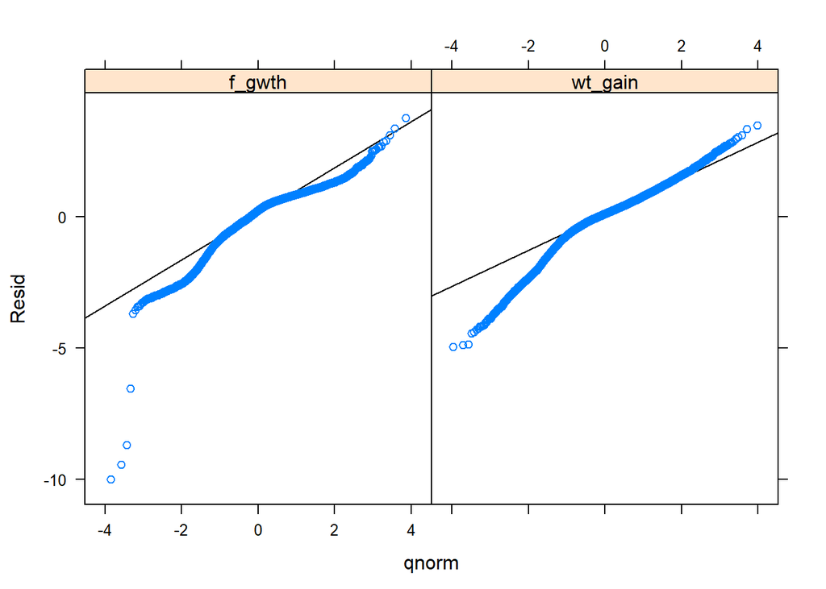

```r
qqmath(~Resid | Variable, data = diagnos, distribution = qnorm,
       prepanel = prepanel.qqmathline,
       panel = function(x, ...) {
         panel.qqmathline(x, ...)
         panel.qqmath(x, ...)
       })
```

#### Residual Vs. Fitted plot for both variables i.e f_gwth and wt_gain

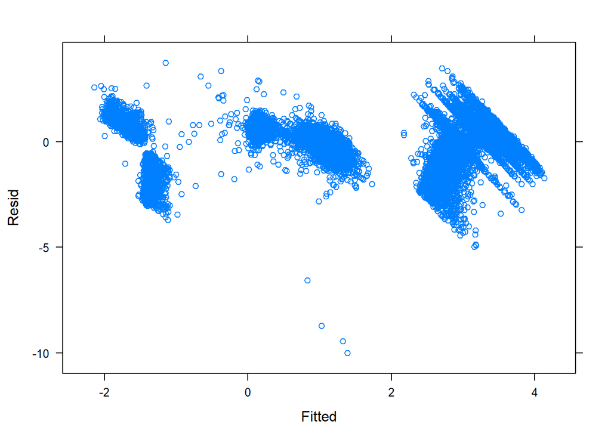

```r
xyplot(Resid ~ Fitted, data = diagnos)
```

#### Residual Vs. Fitted plot seprated by variable.

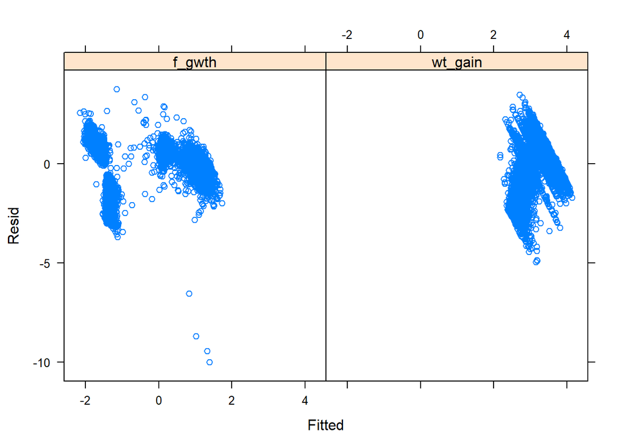

```r
xyplot(Resid ~ Fitted | Variable, data = diagnos)
```